# Nonlinear models and validation

Ireneusz Wojtarowicz

2023-01-23

## Libraries used in the script

```r
library(randomForest)
library(ranger)
library(xgboost)
library(mvtnorm)
library(caret)
library(e1071)
library(Metrics)
library(knitr)
library(tidyverse)
library(gbm)
library(RSNNS)
```

## Data generation

For the purposes of this task, synthetic two-dimensional data (x1 and x2) were generated. The number of samples has been set to 1000.

```r
number_of_samples <- 1000
mean <- c(0,0)
sigma <- matrix(c(1, 0.6, 0.6, 1), nrow = 2)
set.seed(77)

non_linear_function <- as.data.frame(rmvnorm(n = number_of_samples, mean = mean, sigma = sigma))
colnames(non_linear_function) <- c("x1", "x2")
```

## Equation and noise

The equation of the non-linear function was derived from the trigonometric functions of the sum and difference of the angles. Then noise generated by rnorm() was added to the function.

```r
non_linear_function <- non_linear_function %>%
  mutate(y_pure = cos(2*x1+0.5*x2) + sin(0.5*x2-8*x1)) %>%
  mutate(y_noise = y_pure + rnorm(number_of_samples, mean = 0, sd = 0.5))
```

## Visualisation of basic function

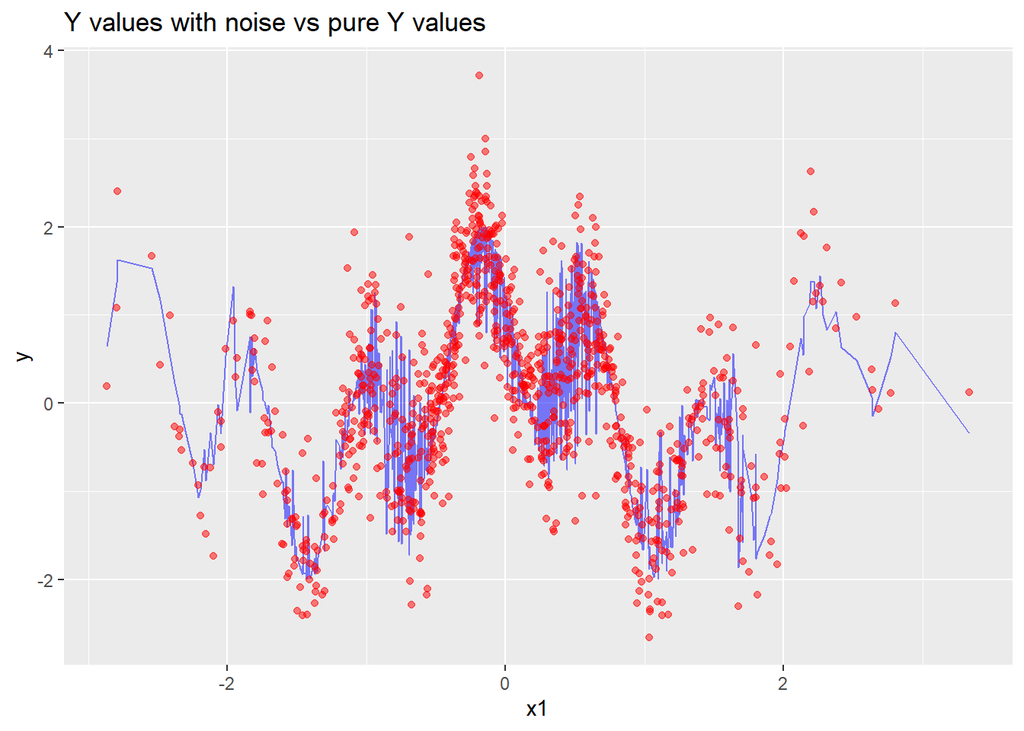

```r
ggplot(non_linear_function, aes(x1, y_noise)) +
  geom_line(aes(y = y_pure), color = "blue", alpha = 0.5) +
  geom_point(aes(y = y_noise), color = "red", alpha = 0.5) +
  labs(
    title = "Y values with noise vs pure Y values",
    x = "x1",
    y = "y",)
```

## Data division

The next stage of the task was to divide the previously prepared data into two subsets: training (75% of the base dataset) and test (25% of the base dataset).

```r
split_data <- createDataPartition(non_linear_function$y_noise, p = 0.75, list = FALSE)
training_data <- non_linear_function[split_data,]
testing_data  <- non_linear_function[-split_data,]
```

## Preparation and tuning of chosen models

Three models were selected to perform the task: Random Forest, XGBoost and SVM.

Random Forest

```r
## Random Forest Model
rnd_forest <- randomForest(
  y_noise ~ .,
  data = training_data,
  ntree = 1000)

## Prediction
testing_data$y_rnd_forest_prediction <- predict(
  rnd_forest,
  testing_data)
```

XGBoost

```r
## XGB Model
xgb <- xgboost(
  data = as.matrix(training_data[, c("x1", "x2")]),
  label = training_data$y_noise,
  nrounds = 100)
## Prediction
testing_data$y_xgb_prediction <- predict(
  xgb,
  as.matrix(testing_data[, c("x1", "x2")]))
```

SVM

```r
## SVM Model
sv_machine <- svm(
  formula = y_noise ~ .,
  data = training_data,
  kernel = "radial",
  cost = 1000)

## Prediction
testing_data$y_sv_machine_prediction <- predict(sv_machine, testing_data)
```

## Visualisation of final results

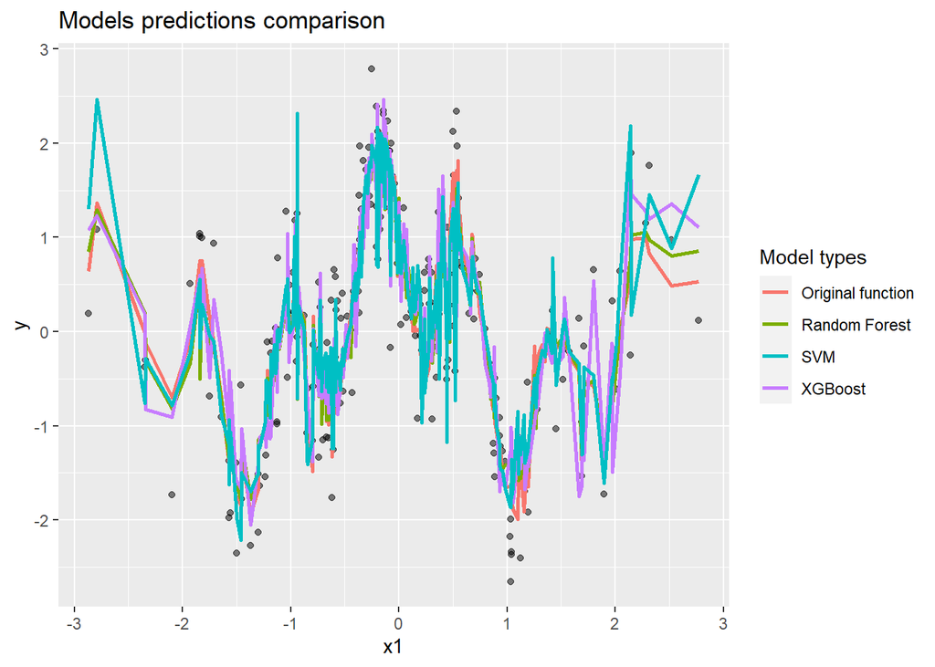

```r
ggplot(testing_data, aes(x1, y_noise)) +
  geom_point(alpha = 0.5) +
  geom_line(aes(y = y_pure, color = "Original function"), size = 1) +
  geom_line(aes(y = y_rnd_forest_prediction, color = "Random Forest"), size = 1) +
  geom_line(aes(y = y_xgb_prediction, color = "XGBoost"), size = 1) +
  geom_line(aes(y = y_sv_machine_prediction, color = "SVM"), size = 1) +
  labs(
    title = "Models predictions comparison",
    x = "x1",
    y = "y",
    color = "Model types")
```

## Calculations

In order to collect data on the basis of which it was possible to compare models and decide which one is more accurate, the following calculations were made: - mean absolute errors - mean square errors

Thanks to this, it was possible to later decide which models achieve the smallest prediction errors.

```r
# Mean Absolute Error
mae_rf  <- mae(testing_data$y_noise, testing_data$y_rnd_forest_prediction)
mae_xgb <- mae(testing_data$y_noise, testing_data$y_xgb_prediction)
mae_svm <- mae(testing_data$y_noise, testing_data$y_sv_machine_prediction)
mae <- c(mae_rf, mae_xgb, mae_svm)

# Mean Square Error
mse_rf  <- mse(testing_data$y_noise, testing_data$y_rnd_forest_prediction)
mse_xgb <- mse(testing_data$y_noise, testing_data$y_xgb_prediction)
mse_svm <- mse(testing_data$y_noise, testing_data$y_sv_machine_prediction)
mse <- c(mse_rf, mse_xgb, mse_svm)
```

## Results and summary

```r
types <- c("Random Forest", "XGBoost", "SVM")
performance_summary <- data.frame(types, mae, mse)
kable(performance_summary, caption = "Performance of differet types of models")
```

Performance of differet types of models

| types | mae | mse |
| --- | --- | --- |
| Random Forest | 0.4107008 | 0.2694714 |
| XGBoost | 0.4745068 | 0.3543291 |
| SVM | 0.4383211 | 0.3226686 |

Based on the table with the results containing the average errors, you can see that the **XGBoost** and **SVM** models have similar values. The **Random Forest** model turned out to be the most effective.